# Inferring a mean and standard deviation

Lee & Wagenmakers Part II. 4.1, p54

cn

2024-03-18

```r
set.seed(12345)

if (!require("pacman", quietly = TRUE)) install.packages("pacman")
if (!require("rjags", quietly = TRUE)) install.packages("rjags")
pacman::p_load(R2jags, psych, cowplot)
pacman::p_load_gh("RLesur/klippy")

klippy::klippy()
```

# 1 Graphic model

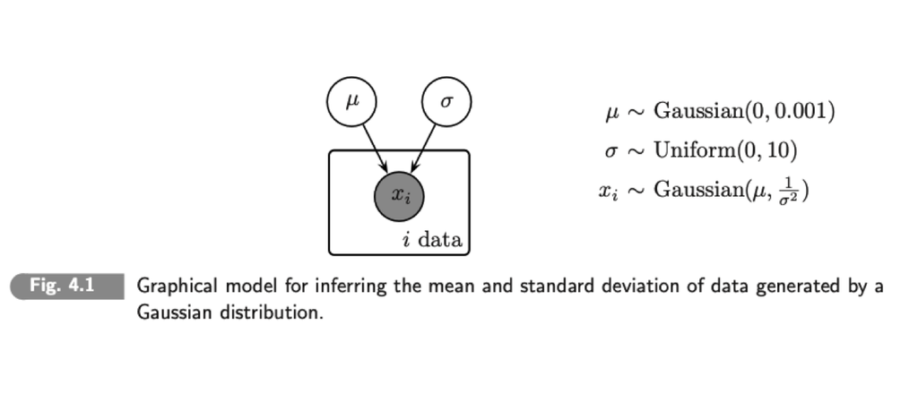

# 2 Running MCMC

## 2.1 Setups

자료와 변수, 초기값, 파라미터를 설정한다. 네 개의 자료로부터 가우시안 분포의 평균과 표준편차를 추정한다.

```r
# 자료
x <- c(1.1, 1.9, 2.3, 1.8)
n <- length(x)

data <- list("x", "n") # to be passed on to JAGS
myinits <- list(
  list(mu = 0, sigma = 1))

# 관찰할 파라미터(parameters to be monitored):
parameters <- c("mu", "sigma")
```

## 2.2 Model & MCMC

WinBUGS에서 가우시안 분포는 평균과 정밀도(precision)를 파라미터로 가진다. 정밀도 $\lambda$와 표준편차 $\sigma$의 관계는 $\lambda = 1/\sigma^2$이다. 표준편차 $\sigma$는 **weakly informative prior**를 쓰기로 한다.

```r
model_text <- "
# Inferring the Mean and Standard Deviation of a Gaussian
model{
  # Data Come From A Gaussian
  for (i in 1:n){
    x[i] ~ dnorm(mu,lambda)
  }
  # Priors
  mu ~ dnorm(0,.001)
  sigma ~ dunif(0,10)
  lambda <- 1/pow(sigma,2)
}
"

samples <- jags(data, inits=myinits, parameters,
                 model.file = textConnection(model_text),
                 n.chains=1, n.iter=10000,
         n.burnin=1, n.thin=1, DIC=T)
```

```
## module glm loaded
```

이제 관찰한 파라미터의 값들이 **samples** 객체에 저장되었으니 자세히 살펴보자.

# 3 Visualization

## 3.1 Raw codes

먼저, `print()`로 요약된 결과를 보자.

```r
print(samples)
```

```
## Inference for Bugs model at "4", fit using jags,
##  1 chains, each with 10000 iterations (first 1 discarded)
##  n.sims = 9999 iterations saved
##          mu.vect sd.vect  2.5%   25%   50%    75%  97.5%
## mu         1.782   0.765 0.343 1.518 1.781  2.036  3.224
## sigma      1.082   1.076 0.319 0.529 0.751  1.180  4.156
## deviance   8.889   4.076 4.758 5.923 7.654 10.520 20.164
##
## DIC info (using the rule, pD = var(deviance)/2)
## pD = 8.3 and DIC = 17.2
## DIC is an estimate of expected predictive error (lower deviance is better).
```

파라미터의 사후분포 표본(posterior samples)을 아래와 같이 빼내어 변수로 저장할 수 있다.

```r
mu    <- samples$BUGSoutput$sims.list$mu
sigma <- samples$BUGSoutput$sims.list$sigma
```

## 3.2 CalvinBayes

가장 먼저 `as.mcmc()`를 통해 `samples`를 mcmc 객체로 변환한다. 이제 `plot()`으로 traceplot과 사후분포를 한꺼번에 확인할 수 있다.

```r
pacman::p_load_gh("rpruim/CalvinBayes")

# 1. 가장 먼저 coda::as.mcmc로 전체 그림을 그린다.
samples.mcmc <- as.mcmc(samples)
head(samples.mcmc)
```

```
## [[1]]
## Markov Chain Monte Carlo (MCMC) output:
## Start = 2
## End = 8
## Thinning interval = 1
##       deviance       mu     sigma
## [1,]  8.426753 1.481645 0.9971671
## [2,] 10.345548 1.892442 1.3792076
## [3,]  7.036731 1.780360 0.8429303
## [4,]  8.361659 1.405206 0.3886182
## [5,]  4.994589 1.885325 0.4005701
## [6,]  5.537748 1.566854 0.5251318
## [7,]  5.647428 1.740296 0.3169917
##
## attr(,"class")
## [1] "mcmc.list"
```

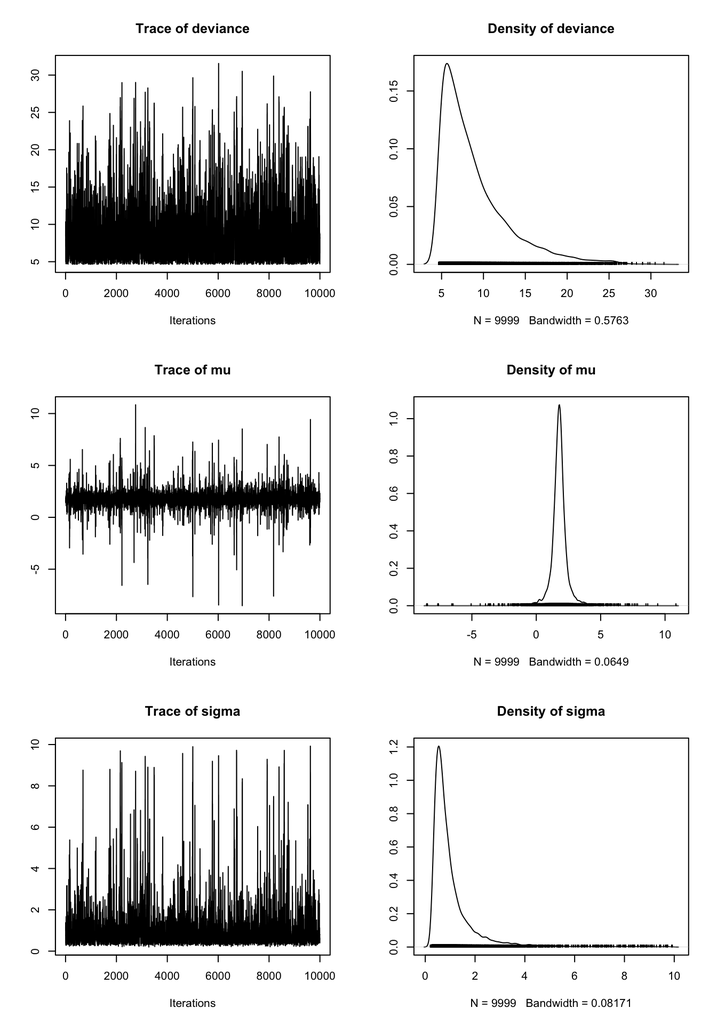

```r
plot(samples.mcmc)
```

`posterior()`는 posterior를 쓰면 samples을 쉽게 꺼낼 수 있다.

```r
p <- posterior(samples) # tidy df로 샘플을 추출한다.
# p <- as_tibble(samples$BUGSoutput$sims.matrix) # 이렇게도 할 수 있다.
psych::headTail(p)
```

```
##      deviance   mu sigma   chain iter
## 1        8.43 1.48     1 chain:1    1
## 2       10.35 1.89  1.38 chain:1    2
## 3        7.04 1.78  0.84 chain:1    3
## 4        8.36 1.41  0.39 chain:1    4
## ...       ...  ...   ...    <NA>  ...
## 9996     5.38 1.67  0.58 chain:1 9996
## 9997      5.6 1.85  0.63 chain:1 9997
## 9998     8.73 2.31  0.57 chain:1 9998
## 9999     6.14 1.49  0.57 chain:1 9999
```

## 3.3 GGDist

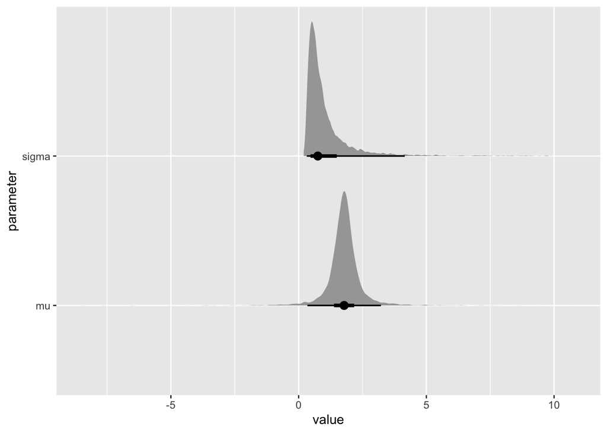

```r
pacman::p_load(tidyverse, ggdist)

p %>% unite("smpl", chain:iter) %>%
    # pivot_longer(!smpl,
    #                        names_to = "parameter",
    #                        values_to = "value") %>%
    pivot_longer(c("mu", "sigma"),
                             names_to = "parameter",
                             values_to = "value") %>%
    ggplot(aes(y = parameter, x = value)) +
    stat_halfeye()
```

## 3.4 Joint Distribution: GGSide

$\mu$와 $\sigma$의 Joint posterior를 그리자. `ggside` 패키지를 써보자.

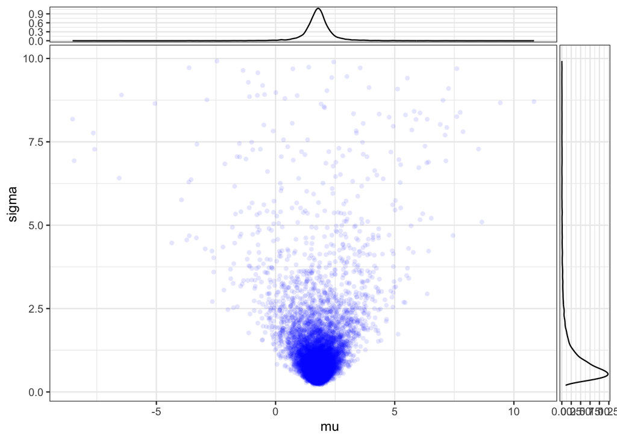

```r
pacman::p_load(ggside)

p %>% ggplot(aes(x = mu, y = sigma)) +
  geom_point(color = "blue", shape = 16, alpha = 1/10) +
  geom_xsidedensity(aes(y=after_stat(density))) +
  geom_ysidedensity(aes(x=after_stat(density))) +
  theme_bw()
```

# 4 Session Info

```r
sessionInfo()
## R version 4.3.3 (2024-02-29)
## Platform: aarch64-apple-darwin20 (64-bit)
## Running under: macOS Sonoma 14.3.1
##
## Matrix products: default
## BLAS:   /Library/Frameworks/R.framework/Versions/4.3-arm64/Resources/lib/libRblas.0.dylib
## LAPACK: /Library/Frameworks/R.framework/Versions/4.3-arm64/Resources/lib/libRlapack.dylib;  LAPACK version 3.11.0
##
## locale:
## [1] en_US.UTF-8/en_US.UTF-8/en_US.UTF-8/C/en_US.UTF-8/en_US.UTF-8
##
## time zone: Asia/Seoul
## tzcode source: internal
##
## attached base packages:
## [1] stats     graphics  grDevices utils     datasets  methods   base
##
## other attached packages:
##  [1] ggside_0.3.1      ggdist_3.3.2      lubridate_1.9.3   forcats_1.0.0
##  [5] stringr_1.5.1     purrr_1.0.2       readr_2.1.5       tidyr_1.3.1
##  [9] tibble_3.2.1      tidyverse_2.0.0   CalvinBayes_0.2.6 bayesplot_1.11.1
## [13] ggformula_0.12.0  ggridges_0.5.6    scales_1.3.0      ggplot2_3.5.0
## [17] dplyr_1.1.4       klippy_0.0.0.9500 cowplot_1.1.3     psych_2.4.1
## [21] R2jags_0.7-1.1    rjags_4-15        coda_0.19-4.1     pacman_0.5.1
##
## loaded via a namespace (and not attached):
##   [1] tensorA_0.36.2.1     rstudioapi_0.15.0    jsonlite_1.8.8
##   [4] R2WinBUGS_2.1-22.1   magrittr_2.0.3       TH.data_1.1-2
##   [7] estimability_1.5     magick_2.8.3         farver_2.1.1
##  [10] rmarkdown_2.26       vctrs_0.6.5          base64enc_0.1-3
##  [13] htmltools_0.5.7      distributional_0.4.0 curl_5.2.1
##  [16] haven_2.5.4          broom_1.0.5          sass_0.4.9
##  [19] StanHeaders_2.32.6   bslib_0.6.1          htmlwidgets_1.6.4
##  [22] plyr_1.8.9           sandwich_3.1-0       emmeans_1.10.0
##  [25] zoo_1.8-12           cachem_1.0.8         igraph_2.0.3
##  [28] mime_0.12            lifecycle_1.0.4      pkgconfig_2.0.3
##  [31] colourpicker_1.3.0   Matrix_1.6-5         R6_2.5.1
##  [34] fastmap_1.1.1        shiny_1.8.0          digest_0.6.35
##  [37] colorspace_2.1-0     brms_2.20.4          crosstalk_1.2.1
##  [40] labeling_0.4.3       timechange_0.3.0     fansi_1.0.6
##  [43] abind_1.4-5          compiler_4.3.3       withr_3.0.0
##  [46] backports_1.4.1      inline_0.3.19        shinystan_2.6.0
##  [49] QuickJSR_1.1.3       pkgbuild_1.4.4       highr_0.10
##  [52] MASS_7.3-60.0.1      gtools_3.9.5         loo_2.7.0
##  [55] tools_4.3.3          httpuv_1.6.14        threejs_0.3.3
##  [58] glue_1.7.0           nlme_3.1-164         promises_1.2.1
##  [61] grid_4.3.3           checkmate_2.3.1      ggdag_0.2.12
##  [64] reshape2_1.4.4       generics_0.1.3       gtable_0.3.4
##  [67] tzdb_0.4.0           labelled_2.12.0      hms_1.1.3
##  [70] tidygraph_1.3.1      utf8_1.2.4           pillar_1.9.0
##  [73] markdown_1.12        posterior_1.5.0      later_1.3.2
##  [76] splines_4.3.3        lattice_0.22-5       survival_3.5-8
##  [79] tidyselect_1.2.1     miniUI_0.1.1.1       knitr_1.45
##  [82] gridExtra_2.3        V8_4.4.2             stats4_4.3.3
##  [85] xfun_0.42            bridgesampling_1.1-2 mosaicCore_0.9.4.0
##  [88] matrixStats_1.2.0    DT_0.32              rstan_2.32.6
##  [91] stringi_1.8.3        yaml_2.3.8           boot_1.3-30
##  [94] evaluate_0.23        codetools_0.2-19     cli_3.6.2
##  [97] RcppParallel_5.1.7   shinythemes_1.2.0    xtable_1.8-4
## [100] munsell_0.5.0        jquerylib_0.1.4      Rcpp_1.0.12
## [103] parallel_4.3.3       rstantools_2.4.0     ellipsis_0.3.2
## [106] assertthat_0.2.1     dygraphs_1.1.1.6     Brobdingnag_1.2-9
## [109] mvtnorm_1.2-4        xts_0.13.2           rlang_1.1.3
## [112] multcomp_1.4-25      mnormt_2.1.1         shinyjs_2.1.0
```